# Importando e lendo o Dataframe com a biblioteca Pandas

```python
import pandas as pd
noshow = pd.read_csv('KaggleV2-May-2016.csv',sep = ',')
noshow.head(3)
```

|  | PatientId | AppointmentID | Gender | ScheduledDay | AppointmentDay | Age | Neighbourhood | Scholarship | Hipertension | Diabetes | Alcoholism | Handcap | SMS_received | No-show |
| --- | --- | --- | --- | --- | --- | --- | --- | --- | --- | --- | --- | --- | --- | --- |
| 0 | 2.987250e+13 | 5642903 | F | 2016-04-29T18:38:08Z | 2016-04-29T00:00:00Z | 62 | JARDIM DA PENHA | 0 | 1 | 0 | 0 | 0 | 0 | No |
| 1 | 5.589978e+14 | 5642503 | M | 2016-04-29T16:08:27Z | 2016-04-29T00:00:00Z | 56 | JARDIM DA PENHA | 0 | 0 | 0 | 0 | 0 | 0 | No |
| 2 | 4.262962e+12 | 5642549 | F | 2016-04-29T16:19:04Z | 2016-04-29T00:00:00Z | 62 | MATA DA PRAIA | 0 | 0 | 0 | 0 | 0 | 0 | No |

# Verificando a presença de valores nulos dentro do dataframe

```python
noshow.isna().sum()
```

```
PatientId         0
AppointmentID     0
Gender            0
ScheduledDay      0
AppointmentDay    0
Age               0
Neighbourhood     0
Scholarship       0
Hipertension      0
Diabetes          0
Alcoholism        0
Handcap           0
SMS_received      0
No-show           0
dtype: int64
```

# Relação entre a Variável Target (noshow) com todas as variáveis categóricas do dataframe

```python
print('--> No-show vs Alcoholism')
print(noshow.groupby(['No-show','Alcoholism'])['PatientId'].count())
print('-------------------------------------------------------------------')

print('--> No-show vs Diabetes')
print(noshow.groupby(['No-show','Diabetes'])['PatientId'].count())
print('-------------------------------------------------------------------')

print('--> No-show vs SMS_received')
print(noshow.groupby(['No-show','SMS_received'])['PatientId'].count())
print('-------------------------------------------------------------------')


print('--> No-show vs Hipertension')
print(noshow.groupby(['No-show','Hipertension'])['PatientId'].count())
print('-------------------------------------------------------------------')

print('--> No-show vs Scholarship')
print(noshow.groupby(['No-show','Scholarship'])['PatientId'].count())
print('-------------------------------------------------------------------')

print('--> No-show vs Handcap')
print(noshow.groupby(['No-show','Handcap'])['PatientId'].count())
print('-------------------------------------------------------------------')

print('--> No-show vs Gender')
print(noshow.groupby(['No-show','Gender'])['PatientId'].count())
print('-------------------------------------------------------------------')
```

```
--> No-show vs Alcoholism
No-show  Alcoholism
No       0             85525
         1              2683
Yes      0             21642
         1               677
Name: PatientId, dtype: int64
-------------------------------------------------------------------
--> No-show vs Diabetes
No-show  Diabetes
No       0           81695
         1            6513
Yes      0           20889
         1            1430
Name: PatientId, dtype: int64
-------------------------------------------------------------------
--> No-show vs SMS_received
No-show  SMS_received
No       0               62510
         1               25698
Yes      0               12535
         1                9784
Name: PatientId, dtype: int64
-------------------------------------------------------------------
--> No-show vs Hipertension
No-show  Hipertension
No       0               70179
         1               18029
Yes      0               18547
         1                3772
Name: PatientId, dtype: int64
-------------------------------------------------------------------
--> No-show vs Scholarship
No-show  Scholarship
No       0              79925
         1               8283
Yes      0              19741
         1               2578
Name: PatientId, dtype: int64
-------------------------------------------------------------------
--> No-show vs Handcap
No-show  Handcap
No       0          86374
         1           1676
         2            146
         3             10
         4              2
Yes      0          21912
         1            366
         2             37
         3              3
         4              1
Name: PatientId, dtype: int64
-------------------------------------------------------------------
--> No-show vs Gender
No-show  Gender
No       F         57246
         M         30962
Yes      F         14594
         M          7725
Name: PatientId, dtype: int64
-------------------------------------------------------------------
```

# Idade das pessoas que tiveram desfecho positivo para noshow

```python
print('No-show Yes')
print(noshow.loc[noshow['No-show'] == 'Yes','Age'].describe())
```

```
No-show Yes
count    22319.000000
mean        34.317667
std         21.965941
min          0.000000
25%         16.000000
50%         33.000000
75%         51.000000
max        115.000000
Name: Age, dtype: float64
```

# Idade das pessoas que tiveram desfecho negativo para noshow

```python
print('No-show NO')
print(noshow.loc[noshow['No-show'] == 'No','Age'].describe())
```

```
No-show NO
count    88208.000000
mean        37.790064
std         23.338878
min         -1.000000
25%         18.000000
50%         38.000000
75%         56.000000
max        115.000000
Name: Age, dtype: float64
```

```python
import numpy as np
median_noshow_no = 38.0
noshow['Age'] = np.where(noshow['Age']<1,median_noshow_no,noshow['Age'])
print('No-show = Não com ajuste')
print('----------------------------')
print(noshow.loc[noshow['No-show'] == 'No','Age'].describe()) #nova descrição de idade
```

```
No-show = Não com ajuste
----------------------------
count    88208.000000
mean        39.039826
std         22.274966
min          1.000000
25%         21.000000
50%         38.000000
75%         56.000000
max        115.000000
Name: Age, dtype: float64
```

# Verificando o número e valores distintos para a variável neighbourhood

```python
print('Valores possíveis: ',noshow['Neighbourhood'].unique())
print('-------------------------------------------------------------------')
print('Número de valores distintos: ',len(noshow['Neighbourhood'].unique()))
```

```
Valores possíveis:  ['JARDIM DA PENHA' 'MATA DA PRAIA' 'PONTAL DE CAMBURI' 'REPÚBLICA'
 'GOIABEIRAS' 'ANDORINHAS' 'CONQUISTA' 'NOVA PALESTINA' 'DA PENHA'
 'TABUAZEIRO' 'BENTO FERREIRA' 'SÃO PEDRO' 'SANTA MARTHA' 'SÃO CRISTÓVÃO'
 'MARUÍPE' 'GRANDE VITÓRIA' 'SÃO BENEDITO' 'ILHA DAS CAIEIRAS'
 'SANTO ANDRÉ' 'SOLON BORGES' 'BONFIM' 'JARDIM CAMBURI' 'MARIA ORTIZ'
 'JABOUR' 'ANTÔNIO HONÓRIO' 'RESISTÊNCIA' 'ILHA DE SANTA MARIA'
 'JUCUTUQUARA' 'MONTE BELO' 'MÁRIO CYPRESTE' 'SANTO ANTÔNIO' 'BELA VISTA'
 'PRAIA DO SUÁ' 'SANTA HELENA' 'ITARARÉ' 'INHANGUETÁ' 'UNIVERSITÁRIO'
 'SÃO JOSÉ' 'REDENÇÃO' 'SANTA CLARA' 'CENTRO' 'PARQUE MOSCOSO'
 'DO MOSCOSO' 'SANTOS DUMONT' 'CARATOÍRA' 'ARIOVALDO FAVALESSA'
 'ILHA DO FRADE' 'GURIGICA' 'JOANA D´ARC' 'CONSOLAÇÃO' 'PRAIA DO CANTO'
 'BOA VISTA' 'MORADA DE CAMBURI' 'SANTA LUÍZA' 'SANTA LÚCIA'
 'BARRO VERMELHO' 'ESTRELINHA' 'FORTE SÃO JOÃO' 'FONTE GRANDE'
 'ENSEADA DO SUÁ' 'SANTOS REIS' 'PIEDADE' 'JESUS DE NAZARETH'
 'SANTA TEREZA' 'CRUZAMENTO' 'ILHA DO PRÍNCIPE' 'ROMÃO' 'COMDUSA'
 'SANTA CECÍLIA' 'VILA RUBIM' 'DE LOURDES' 'DO QUADRO' 'DO CABRAL' 'HORTO'
 'SEGURANÇA DO LAR' 'ILHA DO BOI' 'FRADINHOS' 'NAZARETH' 'AEROPORTO'
 'ILHAS OCEÂNICAS DE TRINDADE' 'PARQUE INDUSTRIAL']
-------------------------------------------------------------------
Número de valores distintos:  81
```

# OneHotEncoder nas variavéis categoricas Gender e Handcap

Aplicando OneHotEncoder as variavéis se transformam em novas colunas onde 1 representa o valor afirmativo e 0 o valor negativo

```python
from category_encoders.one_hot import OneHotEncoder
noshow_bin = noshow

binarizar = OneHotEncoder(cols= ['Gender','Handcap'],use_cat_names=True)
binarizar.fit(noshow_bin)
noshow_bin = binarizar.transform(noshow_bin)

noshow_bin.head()
```

|  | PatientId | AppointmentID | Gender_F | Gender_M | ScheduledDay | AppointmentDay | Age | Neighbourhood | Scholarship | Hipertension | Diabetes | Alcoholism | Handcap_0.0 | Handcap_1.0 | Handcap_2.0 | Handcap_3.0 | Handcap_4.0 | SMS_received | No-show |
| --- | --- | --- | --- | --- | --- | --- | --- | --- | --- | --- | --- | --- | --- | --- | --- | --- | --- | --- | --- |
| 0 | 2.987250e+13 | 5642903 | 1 | 0 | 2016-04-29T18:38:08Z | 2016-04-29T00:00:00Z | 62 | JARDIM DA PENHA | 0 | 1 | 0 | 0 | 1 | 0 | 0 | 0 | 0 | 0 | No |
| 1 | 5.589978e+14 | 5642503 | 0 | 1 | 2016-04-29T16:08:27Z | 2016-04-29T00:00:00Z | 56 | JARDIM DA PENHA | 0 | 0 | 0 | 0 | 1 | 0 | 0 | 0 | 0 | 0 | No |
| 2 | 4.262962e+12 | 5642549 | 1 | 0 | 2016-04-29T16:19:04Z | 2016-04-29T00:00:00Z | 62 | MATA DA PRAIA | 0 | 0 | 0 | 0 | 1 | 0 | 0 | 0 | 0 | 0 | No |
| 3 | 8.679512e+11 | 5642828 | 1 | 0 | 2016-04-29T17:29:31Z | 2016-04-29T00:00:00Z | 8 | PONTAL DE CAMBURI | 0 | 0 | 0 | 0 | 1 | 0 | 0 | 0 | 0 | 0 | No |
| 4 | 8.841186e+12 | 5642494 | 1 | 0 | 2016-04-29T16:07:23Z | 2016-04-29T00:00:00Z | 56 | JARDIM DA PENHA | 0 | 1 | 1 | 0 | 1 | 0 | 0 | 0 | 0 | 0 | No |

# Transformação das variáveis date para dia,mes e ano

```python
noshow_bin['ScheduledDay'] = pd.to_datetime(noshow_bin['ScheduledDay'])
noshow_bin['Scheduled_Day'] = 0
noshow_bin['Scheduled_Month'] = 0
noshow_bin['Scheduled_Year'] = 0
for i in range(0,len(noshow_bin)):
    noshow_bin['Scheduled_Day'][i] = (noshow_bin['ScheduledDay'][i]).day
    noshow_bin['Scheduled_Month'][i] = (noshow_bin['ScheduledDay'][i]).month
    noshow_bin['Scheduled_Year'][i] = (noshow_bin['ScheduledDay'][i]).year
##############################################################################################

noshow_bin['AppointmentDay'] = pd.to_datetime(noshow_bin['AppointmentDay'])
noshow_bin['Appointment_Day'] = 0
noshow_bin['Appointment_Month'] = 0
noshow_bin['Appointment_Year'] = 0
for i in range(0,len(noshow_bin)):
    noshow_bin['Appointment_Day'][i] = (noshow_bin['AppointmentDay'][i]).day
    noshow_bin['Appointment_Month'][i] = (noshow_bin['AppointmentDay'][i]).month
    noshow_bin['Appointment_Year'][i] = (noshow_bin['AppointmentDay'][i]).year
```

```python
noshow_bin.head(2)
```

|  | PatientId | AppointmentID | Gender_F | Gender_M | ScheduledDay | AppointmentDay | Age | Neighbourhood | Scholarship | Hipertension | ... | Handcap_3.0 | Handcap_4.0 | SMS_received | No-show | Scheduled_Day | Scheduled_Month | Scheduled_Year | Appointment_Day | Appointment_Month | Appointment_Year |
| --- | --- | --- | --- | --- | --- | --- | --- | --- | --- | --- | --- | --- | --- | --- | --- | --- | --- | --- | --- | --- | --- |
| 0 | 2.987250e+13 | 5642903 | 1 | 0 | 2016-04-29 18:38:08+00:00 | 2016-04-29 00:00:00+00:00 | 62.0 | JARDIM DA PENHA | 0 | 1 | ... | 0 | 0 | 0 | No | 29 | 4 | 2016 | 29 | 4 | 2016 |
| 1 | 5.589978e+14 | 5642503 | 0 | 1 | 2016-04-29 16:08:27+00:00 | 2016-04-29 00:00:00+00:00 | 56.0 | JARDIM DA PENHA | 0 | 0 | ... | 0 | 0 | 0 | No | 29 | 4 | 2016 | 29 | 4 | 2016 |

2 rows × 25 columns

# Criando novas variáveis

### Diferença entre a marcação e o atendimento em dias e em mês

```python
#calculando diferenca em dias
noshow_bin['DeltaScheduleAppointment_Days'] =(noshow_bin['Appointment_Day'] - noshow_bin['Scheduled_Day'])

#tratando dados diferenca negativa
noshow_bin['DeltaScheduleAppointment_Days'] = np.where(noshow_bin['DeltaScheduleAppointment_Days'] < -1 ,0,noshow_bin['DeltaScheduleAppointment_Days'] )

#Calculando diferenca em dias
noshow_bin['DeltaScheduleAppointment_Month'] = (noshow_bin['Appointment_Month'] - noshow_bin['Scheduled_Month'])
#Tratando diferença negativa
noshow_bin['DeltaScheduleAppointment_Month'] = np.where(noshow_bin['DeltaScheduleAppointment_Month'] < -1 ,0,noshow_bin['DeltaScheduleAppointment_Month'])
```

# Padronizando das variáveis contínuas

padronização = x - média/desvio padrao O processo faz com que todas minhas variaveis numéricas permanecam na mesma escala

```python
from sklearn import preprocessing
padronizar = preprocessing.StandardScaler().fit(noshow_bin[['Age','Scheduled_Day','Scheduled_Month','Scheduled_Year'
           ,'Appointment_Day','Appointment_Month','Appointment_Year'
          ,'DeltaScheduleAppointment_Days','DeltaScheduleAppointment_Month']])

noshow_bin[['Age','Scheduled_Day','Scheduled_Month','Scheduled_Year'
           ,'Appointment_Day','Appointment_Month','Appointment_Year'
          ,'DeltaScheduleAppointment_Days','DeltaScheduleAppointment_Month']] = padronizar.transform(noshow_bin[['Age','Scheduled_Day','Scheduled_Month','Scheduled_Year'
           ,'Appointment_Day','Appointment_Month','Appointment_Year'
          ,'DeltaScheduleAppointment_Days','DeltaScheduleAppointment_Month']])
```

```python
noshow_bin.head(3)
```

|  | PatientId | AppointmentID | Gender_F | Gender_M | ScheduledDay | AppointmentDay | Age | Neighbourhood | Scholarship | Hipertension | ... | SMS_received | No-show | Scheduled_Day | Scheduled_Month | Scheduled_Year | Appointment_Day | Appointment_Month | Appointment_Year | DeltaScheduleAppointment_Days | DeltaScheduleAppointment_Month |
| --- | --- | --- | --- | --- | --- | --- | --- | --- | --- | --- | --- | --- | --- | --- | --- | --- | --- | --- | --- | --- | --- |
| 0 | 2.987250e+13 | 5642903 | 1 | 0 | 2016-04-29 18:38:08+00:00 | 2016-04-29 00:00:00+00:00 | 1.071960 | JARDIM DA PENHA | 0 | 1 | ... | 0 | No | 1.578047 | -1.150983 | 0.023691 | 1.821974 | -2.55404 | 0.0 | -0.508317 | -0.65743 |
| 1 | 5.589978e+14 | 5642503 | 0 | 1 | 2016-04-29 16:08:27+00:00 | 2016-04-29 00:00:00+00:00 | 0.800509 | JARDIM DA PENHA | 0 | 0 | ... | 0 | No | 1.578047 | -1.150983 | 0.023691 | 1.821974 | -2.55404 | 0.0 | -0.508317 | -0.65743 |
| 2 | 4.262962e+12 | 5642549 | 1 | 0 | 2016-04-29 16:19:04+00:00 | 2016-04-29 00:00:00+00:00 | 1.071960 | MATA DA PRAIA | 0 | 0 | ... | 0 | No | 1.578047 | -1.150983 | 0.023691 | 1.821974 | -2.55404 | 0.0 | -0.508317 | -0.65743 |

3 rows × 27 columns

# Separando alvo das features

```python
x = noshow_bin.loc[:,['Gender_F', 'Gender_M', 'Age', 'Scholarship'
                      , 'Hipertension','Diabetes', 'Alcoholism', 'Handcap_0.0', 'Handcap_1.0'
                      , 'Handcap_2.0','Handcap_3.0', 'Handcap_4.0', 'SMS_received','DeltaScheduleAppointment_Days'
                      ,'DeltaScheduleAppointment_Month','Scheduled_Month','Scheduled_Year'
                      ,'Appointment_Month', 'Appointment_Year']]
y = noshow_bin.loc[:,'No-show']
```

```python
from sklearn.preprocessing import LabelEncoder
labelencoder = LabelEncoder()

x['Gender_F'] = labelencoder.fit_transform(x['Gender_F'])
x['Gender_M'] = labelencoder.fit_transform(x['Gender_M'])
x['Scholarship'] = labelencoder.fit_transform(x['Scholarship'])
x['Hipertension'] = labelencoder.fit_transform(x['Hipertension'])
x['Diabetes'] = labelencoder.fit_transform(x['Diabetes'])
x['Alcoholism'] = labelencoder.fit_transform(x['Alcoholism'])
x['Handcap_0.0'] = labelencoder.fit_transform(x['Handcap_0.0'])
x['Handcap_1.0'] = labelencoder.fit_transform(x['Handcap_1.0'])
x['Handcap_2.0'] = labelencoder.fit_transform(x['Handcap_2.0'])
x['Handcap_3.0'] = labelencoder.fit_transform(x['Handcap_3.0'])
x['Handcap_4.0'] = labelencoder.fit_transform(x['Handcap_4.0'])
x['SMS_received'] = labelencoder.fit_transform(x['SMS_received'])


y = labelencoder.fit_transform(y)
```

# Dividindo o dataframe em 70% treino e 30% teste

```python
from sklearn.model_selection import train_test_split
x_treino, x_teste, y_treino, y_teste = train_test_split(x,y,test_size=0.3,random_state=1)
```

# Xgboost

```
recall: 0.5677966101694916
accuracy: 0.7990289212581803
---------------------------------------------
[[26428  6613]
 [   51    67]]
---------------------------------------------
              precision    recall  f1-score   support

           0       1.00      0.80      0.89     33041
           1       0.01      0.57      0.02       118

    accuracy                           0.80     33159
   macro avg       0.50      0.68      0.45     33159
weighted avg       0.99      0.80      0.88     33159
```

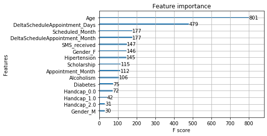

```python
import xgboost as xgb
import matplotlib.pyplot as plt
from sklearn.metrics import recall_score,accuracy_score,classification_report,confusion_matrix

xgboost = xgb.XGBClassifier(objective ='reg:logistic', colsample_bytree = 0.8, learning_rate = 0.1,
                max_depth = 5, alpha = 10, n_estimators = 100,reg_alpha=0.1,random_state=0)
xgboost.fit(x_treino,y_treino)

#realização do predict
previsoes = xgboost.predict(x_teste)

print('recall:' , recall_score(previsoes,y_teste))
print('accuracy:' , accuracy_score(previsoes,y_teste))
print('---------------------------------------------')
print(confusion_matrix(previsoes,y_teste))
print('---------------------------------------------')
print(classification_report(previsoes,y_teste))

xgb.plot_importance(xgboost)
plt.show()
```

# Bagging

Algoritmo baseado em árvores de decisão na qual ele faz a amostragem com repetição (bootstrap) nas instâncias onde cada conjunto de amostras resultará em um modelo diferente, sendo que a previsão final será estimada baseada em hard voting, nesse desafio como estamos tratando de um problema de classificação o valor estimado será baseada na frequencia em relação a previsão de todas arvores de decisão criadas

```python
from sklearn.ensemble import BaggingClassifier
from sklearn.tree import DecisionTreeClassifier
from sklearn.metrics import recall_score,accuracy_score,classification_report,confusion_matrix

modelo = BaggingClassifier(bootstrap=True,n_jobs = -1,n_estimators=100)
modelo.fit(x_treino,y_treino)
previsoes = modelo.predict(x_teste)
print('recall:' , recall_score(previsoes,y_teste))
print('accuracy:' , accuracy_score(previsoes,y_teste))
print('---------------------------------------------')
print(confusion_matrix(previsoes,y_teste))
print('---------------------------------------------')
print(classification_report(previsoes,y_teste))
```

```
recall: 0.3617216117216117
accuracy: 0.771223498899243
---------------------------------------------
[[24388  5495]
 [ 2091  1185]]
---------------------------------------------
              precision    recall  f1-score   support

           0       0.92      0.82      0.87     29883
           1       0.18      0.36      0.24      3276

    accuracy                           0.77     33159
   macro avg       0.55      0.59      0.55     33159
weighted avg       0.85      0.77      0.80     33159
```

# Random Forest

Geralmente é um algoritmo de bagging ou pasting com max_sample ajustada para o número de instancias do meu dataframe,ou seja irá utilizar todas as linhas do dataframe.Além disso, possui uma aleatoriedade nas caracteristicas selecionadas,ou seja para cada árvore de decisão é selecionada um subconjunto de caracteristicas/feautures.Logo nem todas minhas árvores vão ser iguais

```python
from sklearn.ensemble import RandomForestClassifier
from sklearn.metrics import recall_score,accuracy_score,classification_report,confusion_matrix

modelo = RandomForestClassifier(max_depth=10, random_state=0,n_estimators=100)
modelo.fit(x_treino,y_treino)
previsoes = modelo.predict(x_teste)
print('recall:' , recall_score(previsoes,y_teste))
print('accuracy:' , accuracy_score(previsoes,y_teste))
print('---------------------------------------------')
print(confusion_matrix(previsoes,y_teste))
print('---------------------------------------------')
print(classification_report(previsoes,y_teste))
```

```
recall: 0.5416666666666666
accuracy: 0.7986670285593654
---------------------------------------------
[[26457  6654]
 [   22    26]]
---------------------------------------------
              precision    recall  f1-score   support

           0       1.00      0.80      0.89     33111
           1       0.00      0.54      0.01        48

    accuracy                           0.80     33159
   macro avg       0.50      0.67      0.45     33159
weighted avg       1.00      0.80      0.89     33159
```

# Feature Importance do Random Forest

```python
feature = []
for feature in zip(x_treino, modelo.feature_importances_):
    print(feature)
```

```
('Gender_F', 0.007786382950765567)
('Gender_M', 0.008417908461819348)
('Age', 0.1533849218396499)
('Scholarship', 0.015468682384892992)
('Hipertension', 0.014480226501646794)
('Diabetes', 0.00865361474856264)
('Alcoholism', 0.010523745727643197)
('Handcap_0.0', 0.005322114521214223)
('Handcap_1.0', 0.004740942094303707)
('Handcap_2.0', 0.0022871732036165242)
('Handcap_3.0', 0.00044645531163314806)
('Handcap_4.0', 0.0001830804899209252)
('SMS_received', 0.07541449136495672)
('DeltaScheduleAppointment_Days', 0.29440024419473526)
('DeltaScheduleAppointment_Month', 0.23239961725714844)
('Scheduled_Month', 0.14020764117293993)
('Scheduled_Year', 0.00111221531247879)
('Appointment_Month', 0.02477054246207192)
('Appointment_Year', 0.0)
```

# Gradiente Descendente Estocatico

Objetivo ajustar os parametros para minimizar uma funcao de custo para isso é feito iterações para ajustar os parametros que mais ajustem a função, para isso para cada funcao posterior , ou seja i+1, o parametro é calculado da seguinte forma: Supondo que parametro = beta, logo: beta = beta + (taxa_aprendizado x derivada do beta em relação a funcao custo) A taxa de aprendizado deixa a derivada parcial na mesma ordem de grandeza do beta, pois caso a taxa seja grande, são grandes as chances de não ser encontrado o mínimo global da função de custo, porem o contrario faz com que tenhamos um grande custo computacional para encontrarmos o mínimo global.

```python
from sklearn import linear_model
from sklearn.metrics import recall_score,accuracy_score,classification_report,confusion_matrix

modelo= linear_model.SGDClassifier(max_iter=100, tol=1e-3,penalty="l1",random_state=0)
modelo.fit(x_treino,y_treino)
previsoes = modelo.predict(x_teste)
print('recall:' , recall_score(previsoes,y_teste))
print('accuracy:' , accuracy_score(previsoes,y_teste))
print('---------------------------------------------')
print(confusion_matrix(previsoes,y_teste))
print('---------------------------------------------')
print(classification_report(previsoes,y_teste))
```

```
recall: 0.0
accuracy: 0.7985463976597605
---------------------------------------------
[[26479  6680]
 [    0     0]]
---------------------------------------------
              precision    recall  f1-score   support

           0       1.00      0.80      0.89     33159
           1       0.00      0.00      0.00         0

    accuracy                           0.80     33159
   macro avg       0.50      0.40      0.44     33159
weighted avg       1.00      0.80      0.89     33159
```

[output not shown]

### Continua...

Próximos passos: -Pre processamento: criar variável scheduled_weekday, appointment_week,FaixaEtária -Testar validação cruzada k-fold -Testar algoritmos -Feature selection -Tuning de hiperparametros